# How does the right to an education change across groups, countries, and time?

### Brandon Scarlett, Anny Huang, Angelina Qian, Jaroy Wei

- Data Cleaning
- How does being female change your access to education compared to the average?
- Risks to the Right to Education for Women and Girls by Country
- Which country/countries is showing the biggest improvement for females’ rights to education across the last 5 years?
- How does being a part of different social/economic classes change your right to education?

## Data Cleaning

```python
import pandas as pd
import matplotlib.pyplot as plt
```

```python
par = pd.read_csv('csv files/people_at_risk.csv')
```

```python
par["educ_atrisk_prop1"]*100
par.head()
```

|  | country | year | countryyear | iso3c | iso3n | cowcode | hrmicode | food_total_atrisk_resp | food_atrisk_count1 | food_atrisk_prop1 | ... | union_atrisk_count27 | union_atrisk_prop27 | union_atrisk_count28 | union_atrisk_prop28 | union_atrisk_count29 | union_atrisk_prop29 | union_atrisk_count30 | union_atrisk_prop30 | union_atrisk_count31 | union_atrisk_prop31 |
| --- | --- | --- | --- | --- | --- | --- | --- | --- | --- | --- | --- | --- | --- | --- | --- | --- | --- | --- | --- | --- | --- |
| 0 | Angola | 2018 | AGO2018 | AGO | 24.0 | 540.0 | 1 | 11 | 3 | 0.272727 | ... | 1.0 | 0.090909 | 2.0 | 0.181818 | 3.0 | 0.272727 | 4.0 | 0.363636 | 1.0 | 0.090909 |
| 1 | Angola | 2019 | AGO2019 | AGO | 24.0 | 540.0 | 1 | 14 | 3 | 0.214286 | ... | NaN | NaN | NaN | NaN | NaN | NaN | NaN | NaN | NaN | NaN |
| 2 | Angola | 2020 | AGO2020 | AGO | 24.0 | 540.0 | 1 | 13 | 3 | 0.230769 | ... | NaN | NaN | NaN | NaN | NaN | NaN | NaN | NaN | NaN | NaN |
| 3 | Angola | 2021 | AGO2021 | AGO | 24.0 | 540.0 | 1 | 12 | 6 | 0.500000 | ... | NaN | NaN | NaN | NaN | NaN | NaN | NaN | NaN | NaN | NaN |
| 4 | Angola | 2022 | AGO2022 | AGO | 24.0 | 540.0 | 1 | 10 | 5 | 0.500000 | ... | NaN | NaN | NaN | NaN | NaN | NaN | NaN | NaN | NaN | NaN |

5 rows × 1358 columns

```python
esr = pd.read_csv("csv files/esr_sex_disaggregated.csv")
```

```python
selected_columns = [
    'country', 'year',
    'educ_atrisk_prop1',          # Education risks for all
    'food_atrisk_prop1',          # Food risks for all
    'health_atrisk_prop1',        # Health risks for all
    'educ_atrisk_prop10',         # Education risks for Women and girls
    'educ_atrisk_prop26',         # Education Risks for People with low social class
    'food_atrisk_prop10',         # Food risks for women and girls
    'health_atrisk_prop10',       # Health risks for Women and girls
    'health_atrisk_prop26',       # Health risks for Lower social classes
    'food_atrisk_prop26',         # Food risks for lower social classes
]

# Create the new DataFrame
par_focus = par[selected_columns]

# Preview the result
par_focus.head(50)
```

|  | country | year | educ_atrisk_prop1 | food_atrisk_prop1 | health_atrisk_prop1 | educ_atrisk_prop10 | educ_atrisk_prop26 | food_atrisk_prop10 | health_atrisk_prop10 | health_atrisk_prop26 | food_atrisk_prop26 |
| --- | --- | --- | --- | --- | --- | --- | --- | --- | --- | --- | --- |
| 0 | Angola | 2018 | 0.272727 | 0.272727 | 0.545455 | 0.636364 | 0.636364 | 0.454545 | 0.545455 | 0.727273 | 0.818182 |
| 1 | Angola | 2019 | 0.285714 | 0.214286 | 0.571429 | 0.214286 | 0.500000 | 0.071429 | 0.357143 | 0.500000 | 0.642857 |
| 2 | Angola | 2020 | 0.000000 | 0.230769 | 0.307692 | 0.538462 | 0.615385 | 0.307692 | 0.384615 | 0.384615 | 0.692308 |
| 3 | Angola | 2021 | 0.416667 | 0.500000 | 0.666667 | 0.416667 | 0.416667 | 0.250000 | 0.083333 | 0.333333 | 0.333333 |
| 4 | Angola | 2022 | 0.500000 | 0.500000 | 0.500000 | 0.400000 | 0.200000 | 0.500000 | 0.400000 | 0.200000 | 0.200000 |
| 5 | Angola | 2023 | 0.250000 | 0.333333 | 0.333333 | 0.333333 | 0.500000 | 0.250000 | 0.250000 | 0.500000 | 0.500000 |
| 6 | Australia | 2018 | 0.000000 | 0.000000 | 0.066667 | 0.066667 | 0.333333 | 0.133333 | 0.000000 | 0.666667 | 0.600000 |
| 7 | Australia | 2019 | 0.066667 | 0.000000 | 0.000000 | 0.000000 | 0.533333 | 0.000000 | 0.000000 | 0.466667 | 0.733333 |
| 8 | Australia | 2020 | 0.000000 | 0.035714 | 0.000000 | 0.000000 | 0.321429 | 0.035714 | 0.071429 | 0.428571 | 0.500000 |
| 9 | Australia | 2021 | 0.000000 | 0.000000 | 0.000000 | 0.000000 | 0.642857 | 0.000000 | 0.071429 | 0.642857 | 0.714286 |
| 10 | Australia | 2022 | 0.000000 | 0.000000 | 0.000000 | 0.000000 | 0.500000 | 0.000000 | 0.125000 | 0.500000 | 1.000000 |
| 11 | Australia | 2023 | 0.142857 | 0.142857 | 0.142857 | 0.285714 | 0.428571 | 0.285714 | 0.285714 | 0.428571 | 0.428571 |
| 12 | Brazil | 2018 | 0.071429 | 0.214286 | 0.142857 | 0.500000 | 0.642857 | 0.357143 | 0.571429 | 0.785714 | 0.714286 |
| 13 | Brazil | 2019 | 0.080000 | 0.160000 | 0.200000 | 0.240000 | 0.680000 | 0.080000 | 0.280000 | 0.720000 | 0.840000 |
| 14 | Brazil | 2020 | 0.111111 | 0.111111 | 0.500000 | 0.555556 | 0.833333 | 0.333333 | 0.500000 | 0.611111 | 0.777778 |
| 15 | Brazil | 2021 | 0.187500 | 0.250000 | 0.437500 | 0.312500 | 0.625000 | 0.312500 | 0.187500 | 0.437500 | 0.625000 |
| 16 | Brazil | 2022 | 0.111111 | 0.111111 | 0.333333 | 0.444444 | 0.555556 | 0.333333 | 0.222222 | 0.666667 | 0.777778 |
| 17 | Brazil | 2023 | 0.100000 | 0.100000 | 0.100000 | 0.500000 | 0.500000 | 0.500000 | 0.500000 | 0.400000 | 0.600000 |
| 18 | Fiji | 2018 | 0.090909 | 0.090909 | 0.181818 | 0.181818 | 0.545455 | 0.181818 | 0.454545 | 0.636364 | 0.636364 |
| 19 | Fiji | 2019 | 0.058824 | 0.058824 | 0.235294 | 0.000000 | 0.470588 | 0.117647 | 0.117647 | 0.529412 | 0.588235 |
| 20 | Fiji | 2020 | 0.066667 | 0.200000 | 0.266667 | 0.133333 | 0.466667 | 0.200000 | 0.133333 | 0.333333 | 0.466667 |
| 21 | Fiji | 2021 | 0.096774 | 0.193548 | 0.322581 | 0.225806 | 0.387097 | 0.193548 | 0.161290 | 0.258065 | 0.419355 |
| 22 | Fiji | 2022 | 0.153846 | 0.461538 | 0.538462 | 0.153846 | 0.153846 | 0.076923 | 0.076923 | 0.076923 | 0.384615 |
| 23 | Kazakhstan | 2018 | 0.117647 | 0.058824 | 0.352941 | 0.058824 | 0.470588 | 0.058824 | 0.117647 | 0.470588 | 0.470588 |
| 24 | Kazakhstan | 2019 | 0.107143 | 0.214286 | 0.285714 | 0.035714 | 0.357143 | 0.035714 | 0.000000 | 0.464286 | 0.500000 |
| 25 | Kazakhstan | 2020 | 0.090909 | 0.363636 | 0.681818 | 0.000000 | 0.363636 | 0.000000 | 0.000000 | 0.363636 | 0.545455 |
| 26 | Kazakhstan | 2021 | 0.210526 | 0.105263 | 0.421053 | 0.157895 | 0.473684 | 0.105263 | 0.105263 | 0.368421 | 0.578947 |
| 27 | Kazakhstan | 2022 | 0.000000 | 0.230769 | 0.307692 | 0.000000 | 0.384615 | 0.076923 | 0.076923 | 0.461538 | 0.384615 |
| 28 | Kazakhstan | 2023 | 0.235294 | 0.235294 | 0.235294 | 0.235294 | 0.294118 | 0.235294 | 0.176471 | 0.352941 | 0.294118 |
| 29 | Kyrgyzstan | 2018 | 0.105263 | 0.105263 | 0.157895 | 0.157895 | 0.421053 | 0.157895 | 0.157895 | 0.526316 | 0.578947 |
| 30 | Kyrgyzstan | 2019 | 0.076923 | 0.076923 | 0.076923 | 0.153846 | 0.461538 | 0.076923 | 0.076923 | 0.615385 | 0.538462 |
| 31 | Kyrgyzstan | 2020 | 0.500000 | 0.400000 | 0.700000 | 0.000000 | 0.400000 | 0.200000 | 0.100000 | 0.300000 | 0.500000 |
| 32 | Kyrgyzstan | 2021 | 0.050000 | 0.150000 | 0.350000 | 0.450000 | 0.500000 | 0.050000 | 0.450000 | 0.600000 | 0.450000 |
| 33 | Kyrgyzstan | 2022 | 0.214286 | 0.142857 | 0.285714 | 0.142857 | 0.642857 | 0.214286 | 0.357143 | 0.642857 | 0.571429 |
| 34 | Kyrgyzstan | 2023 | 0.100000 | 0.100000 | 0.100000 | 0.300000 | 0.700000 | 0.300000 | 0.300000 | 0.600000 | 0.600000 |
| 35 | Liberia | 2018 | 0.076923 | 0.230769 | 0.153846 | 0.230769 | 0.230769 | 0.230769 | 0.384615 | 0.384615 | 0.153846 |
| 36 | Liberia | 2019 | 0.176471 | 0.294118 | 0.176471 | 0.411765 | 0.294118 | 0.117647 | 0.294118 | 0.411765 | 0.411765 |
| 37 | Liberia | 2020 | 0.357143 | 0.642857 | 0.357143 | 0.285714 | 0.285714 | 0.285714 | 0.500000 | 0.214286 | 0.500000 |
| 38 | Liberia | 2021 | 0.307692 | 0.384615 | 0.384615 | 0.230769 | 0.230769 | 0.076923 | 0.384615 | 0.153846 | 0.230769 |
| 39 | Liberia | 2022 | 0.166667 | 0.416667 | 0.333333 | 0.250000 | 0.166667 | 0.250000 | 0.416667 | 0.333333 | 0.250000 |
| 40 | Liberia | 2023 | 0.312500 | 0.312500 | 0.312500 | 0.375000 | 0.375000 | 0.375000 | 0.375000 | 0.375000 | 0.375000 |
| 41 | Mexico | 2018 | 0.000000 | 0.000000 | 0.142857 | 0.571429 | 1.000000 | 0.428571 | 0.571429 | 0.857143 | 0.857143 |
| 42 | Mexico | 2019 | 0.000000 | 0.000000 | 0.153846 | 0.461538 | 0.615385 | 0.076923 | 0.307692 | 0.538462 | 0.692308 |
| 43 | Mexico | 2020 | 0.133333 | 0.066667 | 0.333333 | 0.066667 | 0.666667 | 0.200000 | 0.266667 | 0.466667 | 0.666667 |
| 44 | Mexico | 2021 | 0.090909 | 0.000000 | 0.090909 | 0.272727 | 0.545455 | 0.000000 | 0.454545 | 0.727273 | 0.909091 |
| 45 | Mexico | 2022 | 0.000000 | 0.166667 | 0.166667 | 0.000000 | 0.833333 | 0.166667 | 0.000000 | 0.833333 | 1.000000 |
| 46 | Mexico | 2023 | 0.125000 | 0.125000 | 0.125000 | 0.250000 | 0.750000 | 0.250000 | 0.500000 | 0.750000 | 0.625000 |
| 47 | Mozambique | 2018 | 0.125000 | 0.000000 | 0.250000 | 0.375000 | 0.500000 | 0.250000 | 0.250000 | 0.750000 | 0.500000 |
| 48 | Mozambique | 2019 | 0.055556 | 0.111111 | 0.166667 | 0.222222 | 0.500000 | 0.111111 | 0.500000 | 0.555556 | 0.555556 |
| 49 | Mozambique | 2020 | 0.200000 | 0.200000 | 0.200000 | 0.400000 | 0.333333 | 0.333333 | 0.400000 | 0.400000 | 0.600000 |

```python
par_focus = par[
    ['country', 'year',
     'educ_atrisk_prop1',
     'food_atrisk_prop1',
     'health_atrisk_prop1',
     'educ_atrisk_prop10',
     'educ_atrisk_prop26',
    'food_atrisk_prop10',
    'health_atrisk_prop10',       # Health risks for Women and girls
    'health_atrisk_prop26',
    'food_atrisk_prop26']
].copy()

# Now safely rename the columns
par_focus.rename(columns={
    'educ_atrisk_prop1': 'Right to Education at Risk for All',
    'food_atrisk_prop1': 'Right to Food At Risk for All',
    'health_atrisk_prop1': 'Right to Health for All',
    'educ_atrisk_prop10': 'Right to Education at Risk for Women and Girls',
    'food_atrisk_prop10': 'Right to Food at Risk for Women and girls' ,
    'health_atrisk_prop10': 'Right to Health for Women and girls',
    'educ_atrisk_prop26': 'Right to Education at Risk for Lower Social Classes',
    'health_atrisk_prop26': 'Right to Health at Risk for Lower Social Classes',
    'food_atrisk_prop26': 'Right to Food at risk for Lower Social Classes'
}, inplace=True)
par_focus.head()
```

|  | country | year | Right to Education at Risk for All | Right to Food At Risk for All | Right to Health for All | Right to Education at Risk for Women and Girls | Right to Education at Risk for Lower Social Classes | Right to Food at Risk for Women and girls | Right to Health for Women and girls | Right to Health at Risk for Lower Social Classes | Right to Food at risk for Lower Social Classes |
| --- | --- | --- | --- | --- | --- | --- | --- | --- | --- | --- | --- |
| 0 | Angola | 2018 | 0.272727 | 0.272727 | 0.545455 | 0.636364 | 0.636364 | 0.454545 | 0.545455 | 0.727273 | 0.818182 |
| 1 | Angola | 2019 | 0.285714 | 0.214286 | 0.571429 | 0.214286 | 0.500000 | 0.071429 | 0.357143 | 0.500000 | 0.642857 |
| 2 | Angola | 2020 | 0.000000 | 0.230769 | 0.307692 | 0.538462 | 0.615385 | 0.307692 | 0.384615 | 0.384615 | 0.692308 |
| 3 | Angola | 2021 | 0.416667 | 0.500000 | 0.666667 | 0.416667 | 0.416667 | 0.250000 | 0.083333 | 0.333333 | 0.333333 |
| 4 | Angola | 2022 | 0.500000 | 0.500000 | 0.500000 | 0.400000 | 0.200000 | 0.500000 | 0.400000 | 0.200000 | 0.200000 |

| Variable | Meaning |
| --- | --- |
| Right to education at risk for all | Proportion of respondents saying all are at risk for a lack of Right to education |
| Right to food at risk for all | Proportion of respondents saying all at risk for a lack of Right to food |
| Right to health at risk for all | Proportion of respondents saying all are at risk for a lack of Right to health |
| Right to education at risk for women and girls | Proportion of respondents saying women and girls at risk for a lack of Right to education |
| Right to education at risk for lower social class | Proportion of respondents saying lower social classes at risk for a lack of Right to education |
| Right to health at risk for women and girls | Proportion of respondents saying women and girls at risk for a lack of right to health |
| Right to food at risk for women and girls | Proportion of respondents saying women and girls at risk for lack of right to food |
| Right to health at risk for lower social class | Proportion of respondents saying lower social classes are at risk for a lack of right to health |
| Right to food at risk for lower social classes | Proportion of respondents saying lower social classes are at risk for a lack of right to food |
| GAPS (education, health, etc.) | The difference between the right being at risk for all and the right being at risk for groups |

## How does being female change your access to education compared to the average?

```python
import numpy as np


par_focus['Gender_Risk_Gap'] = par_focus['Right to Education at Risk for Women and Girls'] - par_focus['Right to Education at Risk for All']
par_focus['Gender_Risk_Ratio'] = np.where(
   par_focus['Right to Education at Risk for All'] == 0,
    np.nan,
   par_focus['Right to Education at Risk for Women and Girls'] / par_focus['Right to Education at Risk for All']
)

print("Descriptive Statistics of Risk Gap and Ratio (with NaNs handled):")
print(par_focus[['Gender_Risk_Gap', 'Gender_Risk_Ratio']].dropna().describe())
```

```
Descriptive Statistics of Risk Gap and Ratio (with NaNs handled):
       Gender_Risk_Gap  Gender_Risk_Ratio
count       107.000000         107.000000
mean          0.053084           1.695327
std           0.201158           1.647950
min          -0.500000           0.000000
25%          -0.071429           0.598214
50%           0.062500           1.285714
75%           0.155870           2.266667
max           0.700000           9.000000
```

The average Gender Risk Gap is approximately +5.3 percentage points, indicating that women and girls face a 5.3% higher risk of losing access to education compared to the general population. The mean Gender Risk Ratio is around 1.70, suggesting that girls and women have a 70% higher chance of being at risk than the average individual. The standard deviation is high (about 0.20 for gap, 1.65 for ratio) and reflects significant variation between different settings. There are instances where women have lower than average risk (min. gap of -0.5), although there are more instances of higher risk.

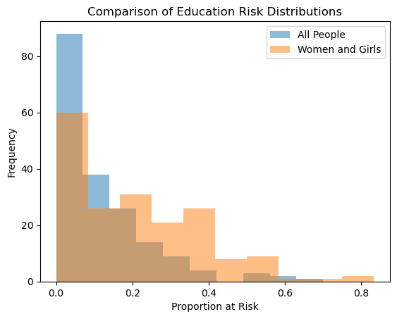

```python
plt.hist(par_focus['Right to Education at Risk for All'], alpha=0.5, label='All People')
plt.hist(par_focus['Right to Education at Risk for Women and Girls'], alpha=0.5, label='Women and Girls')
plt.legend()
plt.title("Comparison of Education Risk Distributions")
plt.xlabel("Proportion at Risk")
plt.ylabel("Frequency")
plt.show()
```

The orange (Women and Girls) distribution stretches higher and further right than the blue (All People) distribution. Women and girls are more likely to fall into higher-risk brackets compared to the overall population.

```
Percentage of cases where women face higher educational risk than the average: 55.68%

T-Test Result: t-statistic = 6.485, p-value = 0.000
```

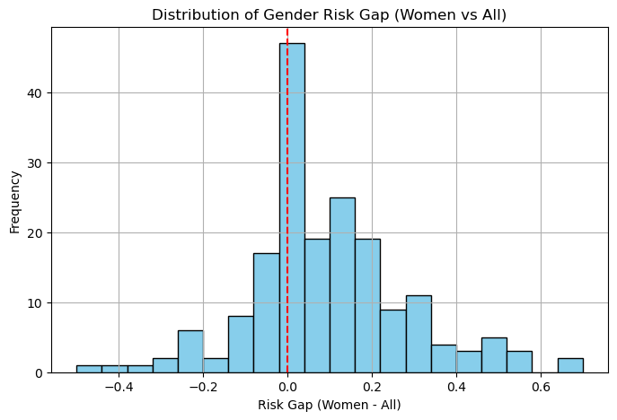

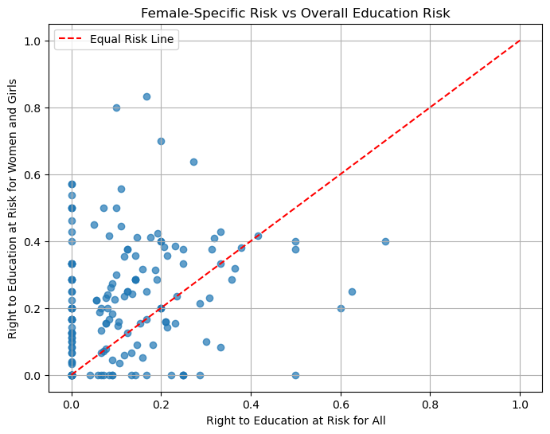

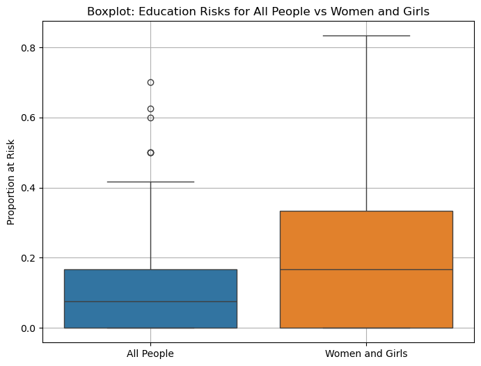

```python
import seaborn as sns
from scipy.stats import ttest_rel

par_focus['High_Female_Risk'] = par_focus['Gender_Risk_Gap'] > 0
high_risk_percentage = par_focus['High_Female_Risk'].mean() * 100
print(f"\nPercentage of cases where women face higher educational risk than the average: {high_risk_percentage:.2f}%")

t_stat, p_val = ttest_rel(par_focus['Right to Education at Risk for Women and Girls'],
                          par_focus['Right to Education at Risk for All'])
print(f"\nT-Test Result: t-statistic = {t_stat:.3f}, p-value = {p_val:.3f}")

plt.figure(figsize=(8, 5))
plt.hist(par_focus['Gender_Risk_Gap'], bins=20, color='skyblue', edgecolor='black')
plt.axvline(0, color='red', linestyle='--')
plt.title('Distribution of Gender Risk Gap (Women vs All)')
plt.xlabel('Risk Gap (Women - All)')
plt.ylabel('Frequency')
plt.grid(True)
plt.show()

plt.figure(figsize=(8,6))
plt.scatter(par_focus['Right to Education at Risk for All'],
            par_focus['Right to Education at Risk for Women and Girls'], alpha=0.7)
plt.plot([0,1],[0,1],'r--', label="Equal Risk Line")
plt.xlabel('Right to Education at Risk for All')
plt.ylabel('Right to Education at Risk for Women and Girls')
plt.title('Female-Specific Risk vs Overall Education Risk')
plt.legend()
plt.grid(True)
plt.show()

plt.figure(figsize=(8,6))
sns.boxplot(data=par_focus[['Right to Education at Risk for All', 'Right to Education at Risk for Women and Girls']])
plt.title('Boxplot: Education Risks for All People vs Women and Girls')
plt.ylabel('Proportion at Risk')
plt.xticks([0, 1], ['All People', 'Women and Girls'])
plt.grid(True)
plt.show()

threshold = 0.5
extreme_cases = par_focus
```

## Risks to the Right to Education for Women and Girls by Country

```python
## Calculating country based education risk gap for women over the time period
# Step 1: Filter the dataset for the two years of interest
par_focus_2018 = par_focus[par_focus['year'] == 2018].copy()
par_focus_2019 = par_focus[par_focus['year'] == 2019].copy()
par_focus_2020 = par_focus[par_focus['year'] == 2020].copy()
par_focus_2021 = par_focus[par_focus['year'] == 2021].copy()
par_focus_2022 = par_focus[par_focus['year'] == 2022].copy()

# Step 2: Calculate education risk gap for women vs all
par_focus_2018['education_gender_gap'] = (
    par_focus_2018['Right to Education at Risk for All'] -
    par_focus_2018['Right to Education at Risk for Women and Girls']

)
par_focus_2019['education_gender_gap'] = (
    par_focus_2019['Right to Education at Risk for All'] -
    par_focus_2019['Right to Education at Risk for Women and Girls']
)
par_focus_2020['education_gender_gap'] = (
    par_focus_2020['Right to Education at Risk for All'] -
    par_focus_2020['Right to Education at Risk for Women and Girls']
)
par_focus_2021['education_gender_gap'] = (
    par_focus_2021['Right to Education at Risk for All'] -
    par_focus_2021['Right to Education at Risk for Women and Girls']
)
par_focus_2022['education_gender_gap'] = (
    par_focus_2022['Right to Education at Risk for All'] -
    par_focus_2022['Right to Education at Risk for Women and Girls']
)
```

### Which countries had the largest shift in womens education rights risks over the 2018-2022 time period?

The education risk gap/education gender gap is the difference between the risks to education access for all in the population and the risks to education access for women and girls in the population. This tells us whether women and girls are better off, in-line with or worst off than the general population. Calculated as (Right to Education at Risk for All - Right to Education at Risk for Women and Girls) When negative then women are at higher risk than the population at large When positive, then women are at lower risk than the overall population

```python
## Finding the country with the largest shift over time
# Merge the two datasets and calculate absolute change
gap_comparison = pd.merge(
    par_focus_2018[['country', 'education_gender_gap']],
    par_focus_2022[['country', 'education_gender_gap']],
    on='country',
    suffixes=('_2018', '_2022')
)

gap_comparison['abs_change'] = (gap_comparison['education_gender_gap_2022'] - gap_comparison['education_gender_gap_2018']).abs()

# Identify the country with the largest absolute change
most_changed = gap_comparison.sort_values(by='abs_change', ascending=False)
most_changed.head()
```

|  | country | education_gender_gap_2018 | education_gender_gap_2022 | abs_change |
| --- | --- | --- | --- | --- |
| 14 | Jordan | -0.500000 | 0.200000 | 0.700000 |
| 13 | DRC | -0.666667 | -0.090909 | 0.575758 |
| 7 | Mexico | -0.571429 | 0.000000 | 0.571429 |
| 0 | Angola | -0.363636 | 0.100000 | 0.463636 |
| 9 | Nepal | 0.000000 | -0.428571 | 0.428571 |

Jordan had the largest change in risk to women's education. In 2018 women were at higher risk with the gap (Education Risk to All - Risk to women) of -0.5. This meant the risks to women were higher than the risk to all. Now the gap has reversed with the risk to all being greater than the risk to women education and an absolute change of 0.7. This marks a drastic improvement in the status of women

### Top 10 countries by absolute magnitude in change in education risks gap for women and girls

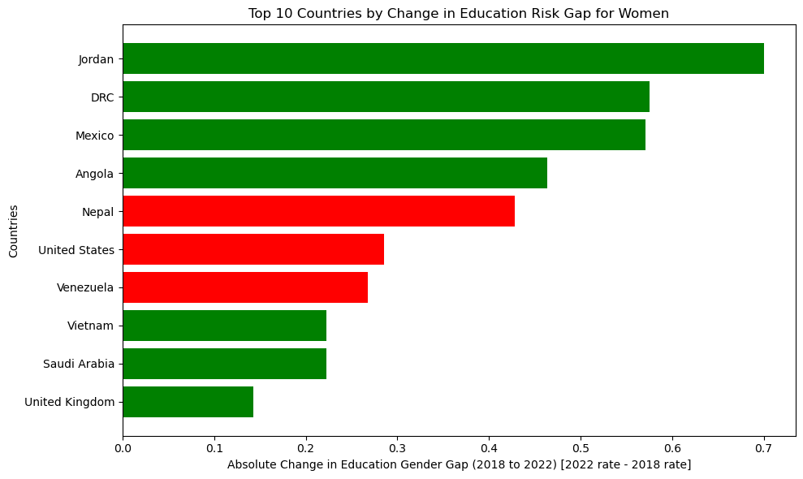

```python
# Sort by absolute change, show top 10 changes
top_changes = gap_comparison.sort_values(by='abs_change', ascending=False).head(10)

# Set up bar color based on direction of change (improvement or worsening for women)
colors = ['green' if row['education_gender_gap_2022'] > row['education_gender_gap_2018'] else 'red'
          for _, row in top_changes.iterrows()]

# Create the bar plot
plt.figure(figsize=(10, 6))
plt.barh(top_changes['country'], top_changes['abs_change'], color=colors)
plt.xlabel('Absolute Change in Education Gender Gap (2018 to 2022) [2022 rate - 2018 rate]')
plt.ylabel('Countries')
plt.title('Top 10 Countries by Change in Education Risk Gap for Women')
plt.gca().invert_yaxis()
plt.tight_layout()
plt.show()
```

green = improvement in the status of women, red = decline in the status of women

When we plot the largest absolute changes we see that Nepal is the country with the largest deterioration in the education rights of women and girls since 2018

### Which countries on average from 2018-2022 had a greater risk to education of women and girls than the population overall?

```python
# Calculate gender gap
par_focus['education_gender_gap'] = (
    par_focus['Right to Education at Risk for All'] -
    par_focus['Right to Education at Risk for Women and Girls']
)

# Filter years 2018–2022
filtered = par_focus[par_focus['year'].between(2018, 2022)]

# Compute average gap by country
avg_gap_by_country = filtered.groupby('country')['education_gender_gap'].mean()

# Separate countries into negative vs positive gap lists
negative_gap_countries = avg_gap_by_country[avg_gap_by_country < 0].index.tolist()
positive_gap_countries = avg_gap_by_country[avg_gap_by_country > 0].index.tolist()

negative_gap_countries
```

```
['Angola',
 'Bangladesh',
 'Brazil',
 'China',
 'Cook Islands',
 'DRC',
 'FSM',
 'Fiji',
 'India',
 'Kiribati',
 'Liberia',
 'Malaysia',
 'Maldives',
 'Marshall Islands',
 'Mexico',
 'Mozambique',
 'Nepal',
 'New Caledonia',
 'New Zealand',
 'Northern Mariana Islands',
 'Samoa',
 'Saudi Arabia',
 'Solomon Islands',
 'Taiwan',
 'Tonga',
 'United Kingdom',
 'United States',
 'Vanuatu',
 'Vietnam']
```

### Which countries on average from 2018-2022 had a lower risk to education of women and girls than the population overall?

```python
positive_gap_countries
```

```
['French Polynesia',
 'Guam',
 'Jordan',
 'Kazakhstan',
 'Kyrgyzstan',
 'PNG',
 'Tuvalu',
 'Venezuela']
```

### Which countries on average from 2018-2022 had an equal risk to education of women and girls with the population overall?

```python
zero_gap_countries = avg_gap_by_country[avg_gap_by_country == 0].index.tolist()
zero_gap_countries
```

```
['American Samoa',
 'Australia',
 'Hong Kong',
 'Nauru',
 'Niue',
 'South Korea',
 'Thailand']
```

## Which country/countries is showing the biggest improvement for females’ rights to education across the last 5 years?

```python
# Filter necessary columns
edu_female = par_focus[['country', 'year', 'Right to Education at Risk for Women and Girls']].dropna()

# For each country, get earliest and latest value within the last 5 years
latest_year = edu_female['year'].max()
five_years_ago = latest_year - 5

recent_data = edu_female[edu_female['year'] >= five_years_ago]
```

```python
# Get change over time per country
change = (
    recent_data
    .sort_values(['country', 'year'])
    .groupby('country')
    .agg(first_year=('year', 'first'),
         last_year=('year', 'last'),
         start_val=('Right to Education at Risk for Women and Girls', 'first'),
         end_val=('Right to Education at Risk for Women and Girls', 'last'))
    .assign(change=lambda x: x['start_val'] - x['end_val'])  # drop in par_focus = improvement
    .sort_values('change', ascending=False)
)

# Display top improving country
top_improver = change.iloc[0]
print(f"Country with biggest improvement: {top_improver.name}")
print(f"Drop in par_focus over 5 years: {top_improver['change']:.2f}")
```

```
Country with biggest improvement: DRC
Drop in par_focus over 5 years: 0.68
```

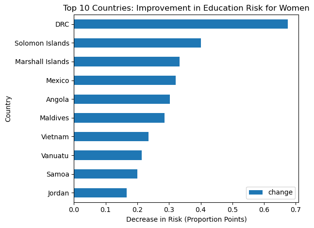

```python
# Visualization - Barplot
import matplotlib.pyplot as plt

change.head(10).plot(kind='barh', y='change', title='Top 10 Countries: Improvement in Education Risk for Women')
plt.xlabel('Decrease in Risk (Proportion Points)')
plt.ylabel('Country')
plt.gca().invert_yaxis()
plt.tight_layout()
plt.show()
```

Between 2018 and 2023, the Democratic Republic of the Congo (DRC) showed the greatest improvement in women and girls’ access to education. Specifically, the proportion of survey respondents identifying women and girls as being at par_focus of being denied the right to education decreased by 68 percentage points over this five-year period.

### 2018 vs 2022 Change in Risks to Women's Access to Education by Continent

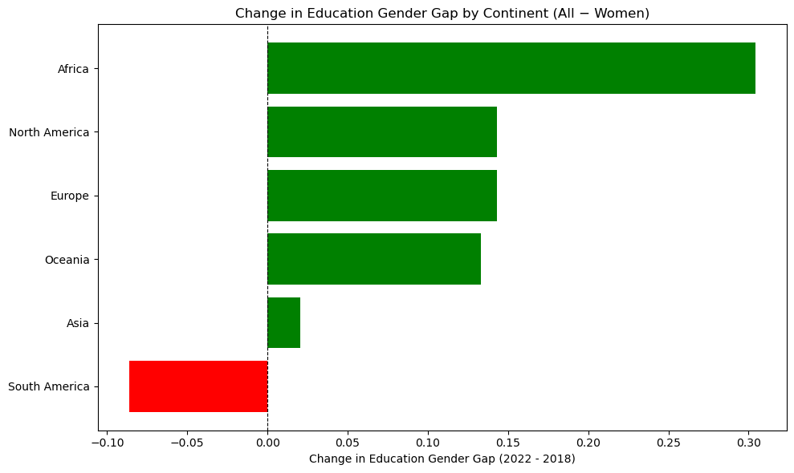

```python
relevant_country_continent_map = {
    # Africa
    'Angola': 'Africa', 'DRC': 'Africa', 'Liberia': 'Africa', 'Mozambique': 'Africa',

    # Asia
    'Bangladesh': 'Asia', 'China': 'Asia', 'Hong Kong': 'Asia', 'India': 'Asia',
    'Jordan': 'Asia', 'Kazakhstan': 'Asia', 'Kyrgyzstan': 'Asia', 'Malaysia': 'Asia',
    'Maldives': 'Asia', 'Nepal': 'Asia', 'Saudi Arabia': 'Asia', 'Singapore': 'Asia',
    'South Korea': 'Asia', 'Sri Lanka': 'Asia', 'Taiwan': 'Asia', 'Thailand': 'Asia',
    'Vietnam': 'Asia',

    # Oceania
    'Australia': 'Oceania', 'Cook Islands': 'Oceania', 'FSM': 'Oceania', 'Fiji': 'Oceania',
    'French Polynesia': 'Oceania', 'Kiribati': 'Oceania', 'Marshall Islands': 'Oceania',
    'Nauru': 'Oceania', 'New Caledonia': 'Oceania', 'New Zealand': 'Oceania', 'Niue': 'Oceania',
    'Northern Mariana Islands': 'Oceania', 'PNG': 'Oceania', 'Samoa': 'Oceania',
    'Solomon Islands': 'Oceania', 'Tonga': 'Oceania', 'Tuvalu': 'Oceania', 'Vanuatu': 'Oceania',

    # North America
    'Guam': 'North America', 'Mexico': 'North America', 'United States': 'North America',
    'American Samoa': 'North America',

    # South America
    'Brazil': 'South America', 'Venezuela': 'South America',

    # Europe
    'United Kingdom': 'Europe'
}

# STEP 2: Apply mapping to entire dataset
par_focus['continent'] = par_focus['country'].map(relevant_country_continent_map)

# STEP 3: Subset to 2018 and 2022 and calculate education gender gap

par_focus_2018['continent'] = par_focus_2018['country'].map(relevant_country_continent_map)
par_focus_2022['continent'] = par_focus_2022['country'].map(relevant_country_continent_map)

# STEP 4: Group by continent and compute mean gaps
continent_gap_2018 = par_focus_2018.groupby('continent', as_index=False)['education_gender_gap'].mean()
continent_gap_2022 = par_focus_2022.groupby('continent', as_index=False)['education_gender_gap'].mean()

# STEP 5: Merge and calculate changes
continent_gap_change = pd.merge(continent_gap_2018, continent_gap_2022, on='continent', suffixes=('_2018', '_2022'))
continent_gap_change['change'] = continent_gap_change['education_gender_gap_2022'] - continent_gap_change['education_gender_gap_2018']

# STEP 6: Plot

continent_gap_change_sorted = continent_gap_change.sort_values(by='change', ascending=False)
colors = ['green' if val > 0 else 'red' for val in continent_gap_change_sorted['change']]

plt.figure(figsize=(10, 6))
plt.barh(continent_gap_change_sorted['continent'], continent_gap_change_sorted['change'], color=colors)
plt.axvline(0, color='black', linewidth=0.8, linestyle='--')
plt.xlabel("Change in Education Gender Gap (2022 - 2018)")
plt.title("Change in Education Gender Gap by Continent (All − Women)")
plt.gca().invert_yaxis()
plt.tight_layout()
plt.show()
```

### Table Showing the Difference in each Continent between 2018 and 2022

```python
continent_gap_change_sorted
```

|  | continent | education_gender_gap_2018 | education_gender_gap_2022 | change |
| --- | --- | --- | --- | --- |
| 0 | Africa | -0.358537 | -0.054275 | 0.304262 |
| 3 | North America | -0.285714 | -0.142857 | 0.142857 |
| 2 | Europe | -0.142857 | 0.000000 | 0.142857 |
| 4 | Oceania | -0.052525 | 0.080556 | 0.133081 |
| 1 | Asia | -0.119097 | -0.098891 | 0.020206 |
| 5 | South America | -0.151786 | -0.238095 | -0.086310 |

### Changes in Risks to Womens Education by Continent from 2018-2022

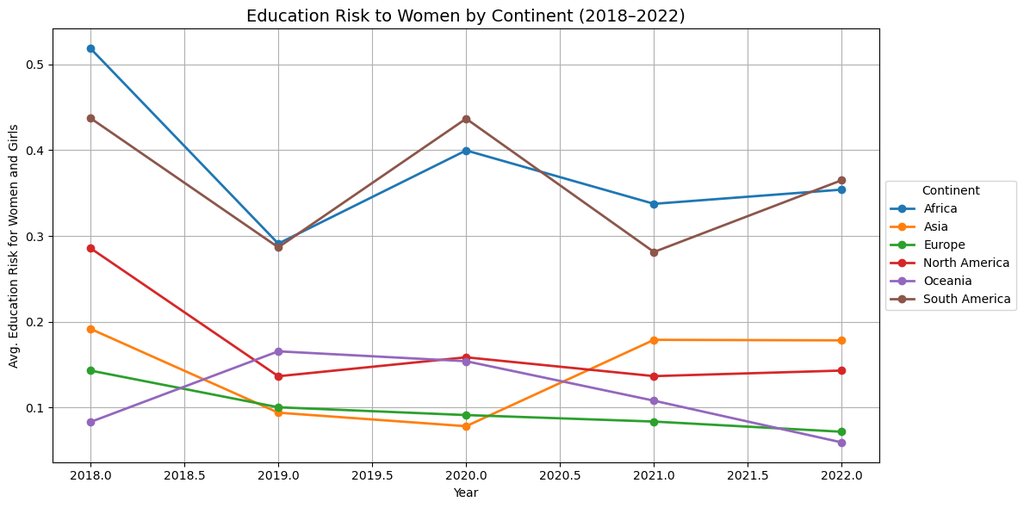

```python
# STEP 1: Rebuild year-specific slices
par_focus_2018 = par_focus[par_focus['year'] == 2018].copy()
par_focus_2019 = par_focus[par_focus['year'] == 2019].copy()
par_focus_2020 = par_focus[par_focus['year'] == 2020].copy()
par_focus_2021 = par_focus[par_focus['year'] == 2021].copy()
par_focus_2022 = par_focus[par_focus['year'] == 2022].copy()

# STEP 2: Combine into a unified DataFrame
par_focus_combined = pd.concat([
    par_focus_2018.assign(year=2018),
    par_focus_2019.assign(year=2019),
    par_focus_2020.assign(year=2020),
    par_focus_2021.assign(year=2021),
    par_focus_2022.assign(year=2022)
])

# STEP 3: Apply continent mapping
par_focus_combined['continent'] = par_focus_combined['country'].map(relevant_country_continent_map)

# STEP 4: Group and pivot for line chart
trend_grouped = par_focus_combined.groupby(['year', 'continent'], as_index=False)[
    'Right to Education at Risk for Women and Girls'
].mean()

trend_pivot = trend_grouped.pivot(index='year', columns='continent', values='Right to Education at Risk for Women and Girls')

# STEP 5: Plot line chart cleanly using Axes object
ax = trend_pivot.plot(
    figsize=(12, 6),
    marker='o',
    linewidth=2,
    markersize=6
)

# Format plot labels, title, and legend
ax.set_title('Education Risk to Women by Continent (2018–2022)', fontsize=14)
ax.set_ylabel('Avg. Education Risk for Women and Girls')
ax.set_xlabel('Year')
ax.grid(True)

# Move legend outside the plot area
ax.legend(title='Continent', loc='center left', bbox_to_anchor=(1.0, 0.5))

# Adjust layout to prevent clipping
plt.tight_layout()
plt.show()
```

## How does being a part of different social/economic classes change your right to education?

```python
par_focus.iloc[:, 2:] = par_focus.iloc[:, 2:] * 100
par_focus.head()
```

|  | country | year | Right to Education at Risk for All | Right to Food At Risk for All | Right to Health for All | Right to Education at Risk for Women and Girls | Right to Education at Risk for Lower Social Classes | Right to Food at Risk for Women and girls | Right to Health for Women and girls | Right to Health at Risk for Lower Social Classes | Right to Food at risk for Lower Social Classes | Gender_Risk_Gap | Gender_Risk_Ratio | High_Female_Risk | education_gender_gap | continent |
| --- | --- | --- | --- | --- | --- | --- | --- | --- | --- | --- | --- | --- | --- | --- | --- | --- |
| 0 | Angola | 2018 | 27.272728 | 27.272728 | 54.545456 | 63.636363 | 63.636363 | 45.454547 | 54.545456 | 72.727275 | 81.818181 | 36.363635 | 233.333325 | 100 | -36.363635 | AfricaAfricaAfricaAfricaAfricaAfricaAfricaAfri... |
| 1 | Angola | 2019 | 28.571430 | 21.428572 | 57.142860 | 21.428572 | 50.000000 | 7.142857 | 35.714287 | 50.000000 | 64.285713 | -7.142858 | 74.999998 | 0 | 7.142858 | AfricaAfricaAfricaAfricaAfricaAfricaAfricaAfri... |
| 2 | Angola | 2020 | 0.000000 | 23.076923 | 30.769232 | 53.846157 | 61.538464 | 30.769232 | 38.461539 | 38.461539 | 69.230771 | 53.846157 | NaN | 100 | -53.846157 | AfricaAfricaAfricaAfricaAfricaAfricaAfricaAfri... |
| 3 | Angola | 2021 | 41.666666 | 50.000000 | 66.666669 | 41.666666 | 41.666666 | 25.000000 | 8.333334 | 33.333334 | 33.333334 | 0.000000 | 100.000000 | 0 | 0.000000 | AfricaAfricaAfricaAfricaAfricaAfricaAfricaAfri... |
| 4 | Angola | 2022 | 50.000000 | 50.000000 | 50.000000 | 40.000001 | 20.000000 | 50.000000 | 40.000001 | 20.000000 | 20.000000 | -9.999999 | 80.000001 | 0 | 9.999999 | AfricaAfricaAfricaAfricaAfricaAfricaAfricaAfri... |

```python
#right to education by groups
par_edu = par[
    ['educ_atrisk_prop1',
     'educ_atrisk_prop10',
     'educ_atrisk_prop26']
].copy()

# Now safely rename the columns
par_edu.rename(columns={
    'educ_atrisk_prop1': 'Right to Education at Risk for All',
    'educ_atrisk_prop10': 'Right to Education at Risk for Women and Girls',
    'educ_atrisk_prop26': 'Right to Education at Risk for Lower Social Classes',
}, inplace=True)
par_edu.head()
```

|  | Right to Education at Risk for All | Right to Education at Risk for Women and Girls | Right to Education at Risk for Lower Social Classes |
| --- | --- | --- | --- |
| 0 | 0.272727 | 0.636364 | 0.636364 |
| 1 | 0.285714 | 0.214286 | 0.500000 |
| 2 | 0.000000 | 0.538462 | 0.615385 |
| 3 | 0.416667 | 0.416667 | 0.416667 |
| 4 | 0.500000 | 0.400000 | 0.200000 |

```python
summary_table = par_edu.describe().T
print(summary_table)
```

```
                                                    count      mean       std  \
Right to Education at Risk for All                  185.0  0.107563  0.133893
Right to Education at Risk for Women and Girls      185.0  0.199419  0.178613
Right to Education at Risk for Lower Social Cla...  185.0  0.430643  0.202387

                                                    min       25%       50%  \
Right to Education at Risk for All                  0.0  0.000000  0.076923
Right to Education at Risk for Women and Girls      0.0  0.000000  0.166667
Right to Education at Risk for Lower Social Cla...  0.0  0.285714  0.433333

                                                         75%       max
Right to Education at Risk for All                  0.166667  0.700000
Right to Education at Risk for Women and Girls      0.333333  0.833333
Right to Education at Risk for Lower Social Cla...  0.571429  1.000000
```

### From the provided statistical summary, we can conclude the following:

#### For all:

- The mean risk is relatively low at **0.1076**, indicating that, **on average, the risk to education for all is minimal**.
- The standard deviation is 0.1339, showing moderate variability in the data.

#### For Women and Girls:

- The mean risk is higher at **0.1994**, indicating that **women and girls face more educational risks compared to the general population**.
- The standard deviation is 0.1786, indicating higher variability compared to the general population.

#### For Lower Social Classes:

- The mean risk is the highest at **0.4306**, suggesting that **lower social classes face the most significant educational risks**.
- The standard deviation is 0.2024, showing considerable variability in the data.

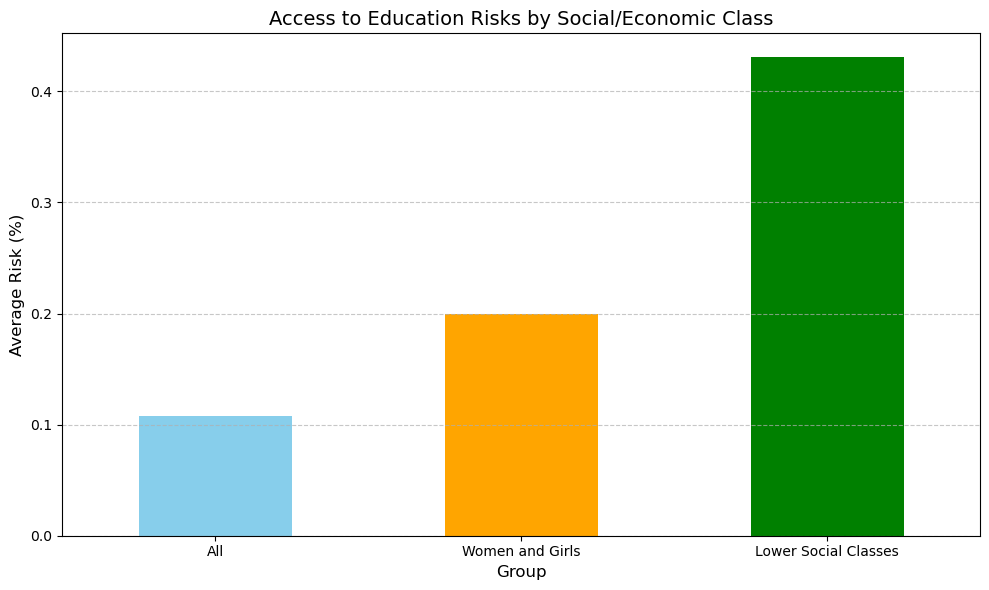

```python
# Filter relevant columns for visualization
education_data = par_edu.rename(columns={
    'Right to Education at Risk for All': 'All',
    'Right to Education at Risk for Women and Girls': 'Women and Girls',
    'Right to Education at Risk for Lower Social Classes': 'Lower Social Classes'
})

# Calculate mean risks for each group
education_means = education_data.mean()

# Plot the data
education_means.plot(kind='bar', figsize=(10, 6), color=['skyblue', 'orange', 'green'])

# Add labels and title
plt.xlabel('Group', fontsize=12)
plt.ylabel('Average Risk (%)', fontsize=12)
plt.title('Access to Education Risks by Social/Economic Class', fontsize=14)
plt.xticks(rotation=0)
plt.grid(axis='y', linestyle='--', alpha=0.7)

# Show the plot
plt.tight_layout()
plt.show()
```

### Conclusion:

- Lower social classes face the highest educational risks, followed by women and girls, and then the general population.
- There is significant variability in the risks across all groups, with some cases showing very high risks.

### Average Risk to Education by Countries From Highest to Lowest

```python
# avg risk ranking by country
# Step 1: Focus on relevant columns
col = "Right to Education at Risk for Lower Social Classes"
df_filtered = par_focus[["country", col]].dropna()

# Step 2: Compute average risk for each country
country_avg_risk = df_filtered.groupby("country")[col].mean().reset_index()

# Step 3: Sort countries by average risk in descending order
country_avg_risk_sorted = country_avg_risk.sort_values(by=col, ascending=False)

# Display the top results
country_avg_risk_sorted
```

|  | country | Right to Education at Risk for Lower Social Classes |
| --- | --- | --- |
| 22 | Mexico | 73.513987 |
| 42 | United States | 71.388889 |
| 4 | Brazil | 63.945767 |
| 29 | Northern Mariana Islands | 57.500000 |
| 44 | Venezuela | 57.321429 |
| 20 | Maldives | 57.142860 |
| 41 | United Kingdom | 55.862821 |
| 25 | Nepal | 55.437272 |
| 19 | Malaysia | 55.416667 |
| 13 | India | 54.223228 |
| 45 | Vietnam | 52.764370 |
| 11 | Guam | 52.222223 |
| 17 | Kyrgyzstan | 52.090804 |
| 27 | New Zealand | 51.837607 |
| 34 | Solomon Islands | 50.079366 |
| 36 | Sri Lanka | 48.275861 |
| 1 | Angola | 47.806915 |
| 23 | Mozambique | 47.539683 |
| 5 | China | 47.530031 |
| 30 | PNG | 47.478023 |
| 10 | French Polynesia | 46.666668 |
| 2 | Australia | 45.992064 |
| 37 | Taiwan | 41.445579 |
| 9 | Fiji | 40.473048 |
| 31 | Samoa | 40.208334 |
| 21 | Marshall Islands | 39.583334 |
| 38 | Thailand | 39.102565 |
| 3 | Bangladesh | 39.075631 |
| 15 | Kazakhstan | 39.063079 |
| 43 | Vanuatu | 37.321429 |
| 7 | DRC | 36.626605 |
| 35 | South Korea | 36.514551 |
| 8 | FSM | 32.500000 |
| 39 | Tonga | 30.681819 |
| 33 | Singapore | 28.571430 |
| 18 | Liberia | 26.383952 |
| 14 | Jordan | 25.972223 |
| 16 | Kiribati | 20.000000 |
| 24 | Nauru | 20.000000 |
| 12 | Hong Kong | 19.345238 |
| 32 | Saudi Arabia | 17.361111 |
| 40 | Tuvalu | 16.666667 |
| 26 | New Caledonia | 15.563910 |
| 6 | Cook Islands | 11.428572 |
| 0 | American Samoa | 10.000000 |
| 28 | Niue | 0.000000 |

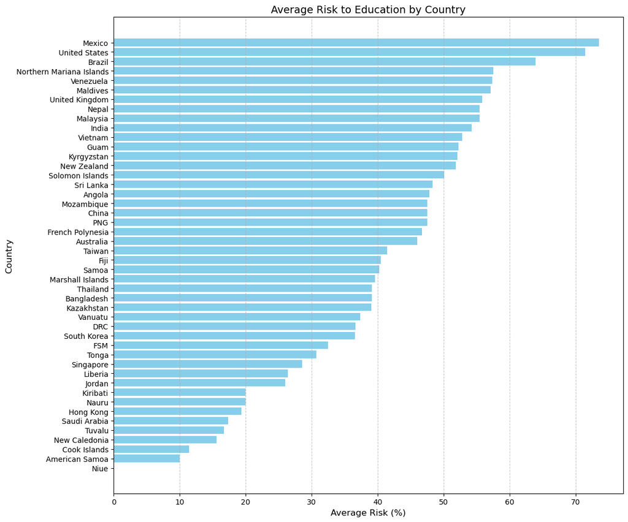

```python
# Create a horizontal bar chart for better readability
plt.figure(figsize=(12, 10))
plt.barh(country_avg_risk_sorted["country"], country_avg_risk_sorted[col], color="skyblue")

# Add labels and title
plt.xlabel("Average Risk (%)", fontsize=12)
plt.ylabel("Country", fontsize=12)
plt.title("Average Risk to Education by Country", fontsize=14)
plt.gca().invert_yaxis()  # Invert y-axis to show the highest risk at the top
plt.grid(axis="x", linestyle="--", alpha=0.7)

# Show the plot
plt.tight_layout()
plt.show()
```

### Correlations Between Health & Education and Food & Education

```python
# Calculate the correlation between health and education risks for lower social classes
health_education_correlation = par_focus[
    ['Right to Education at Risk for Lower Social Classes', 'Right to Health at Risk for Lower Social Classes']
].corr().iloc[0, 1]

# Display the result
health_education_correlation
```

```
0.741186710961005
```

```python
# Calculate the correlation between food and education risks for lower social classes
food_education_correlation = par_focus[
    ['Right to Education at Risk for Lower Social Classes', 'Right to Food at risk for Lower Social Classes']
].corr().iloc[0, 1]

# Display the result
food_education_correlation
```

```
0.729985017028904
```

- There is a strong positive correlation between health & education for lower classes, indicates that where lower-status groups face **higher risks to health rights**, they likewise tend to face notably **higher risks to education rights**.
- Similarly, correlation between food & education for lower classes shows that areas with **greater food rights risk** for lower-status groups also generally experience **elevated risks to education**for those same groups.

### Looking at the correlations by the top 3 countries most risky for education rights

```python
# Define the selected countries (example list, replace with actual countries)
selected_countries = ['Mexico', 'United States', 'Brazil']

# Filter data for the selected countries
filtered_data = par_focus[par_focus['country'].isin(selected_countries)]

# Initialize a dictionary to store the results
correlations = {}

# Loop through each country and calculate correlations
for country in selected_countries:
    country_data = filtered_data[filtered_data['country'] == country]

    # Calculate correlation between health and education
    health_edu_corr = country_data[
        ['Right to Education at Risk for Lower Social Classes', 'Right to Health at Risk for Lower Social Classes']
    ].corr().iloc[0, 1]

    # Calculate correlation between food and education
    food_edu_corr = country_data[
        ['Right to Education at Risk for Lower Social Classes', 'Right to Food at risk for Lower Social Classes']
    ].corr().iloc[0, 1]

    # Store the results
    correlations[country] = {
        'Health vs Education': health_edu_corr,
        'Food vs Education': food_edu_corr
    }

correlations
```

```
{'Mexico': {'Health vs Education': 0.6559673789864796,
  'Food vs Education': 0.26917922389457305},
 'United States': {'Health vs Education': 0.7598473225880283,
  'Food vs Education': 0.9636363340474822},
 'Brazil': {'Health vs Education': 0.3634042778022737,
  'Food vs Education': 0.5410595891086064}}
```

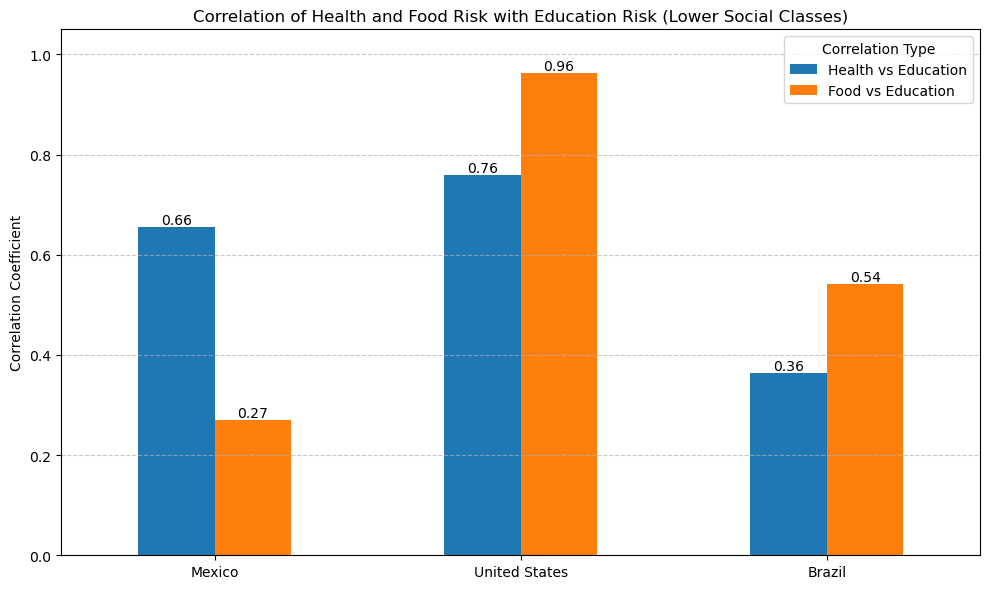

```python
# Convert correlations dictionary to DataFrame for plotting
cor_df = pd.DataFrame(correlations).T

# Plotting
ax = cor_df.plot(kind='bar', figsize=(10, 6), rot=0)
plt.title("Correlation of Health and Food Risk with Education Risk (Lower Social Classes)")
plt.ylabel("Correlation Coefficient")
plt.ylim(0, 1.05)
plt.legend(title="Correlation Type")
plt.grid(axis='y', linestyle='--', alpha=0.7)

# Add data labels
for container in ax.containers:
    ax.bar_label(container, fmt='%.2f', label_type='edge', fontsize=10)

plt.tight_layout()
plt.show()
```

- In the United States, there’s a very strong link between food, health, and education risks. **When food or healthcare access is limited, education for lower-income people is also heavily affected**.
- In Mexico, health and education risks are somewhat connected, but food access doesn’t seem to relate much to education risk.
- In Brazil, the connections between food, health, and education risks are weaker, suggesting that other issues like politics or regional differences may matter more.